# Building grides with rollply

Alexandre Génin

08/06/2015

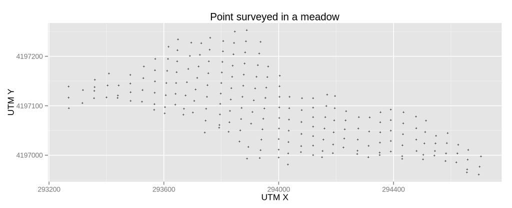

Rollply uses internally a grid of coordinates. For each points of this grid it selects the observations falling within the window, then applies the function using this subset. The user can either provide a grid as a data.frame or rollply will take care of building one automatically.

Several helper functions are provided to build nice 2D grids, they all start with *build_grid_*.

- *build_grid_identical*: builds a grid of regularly-spaced points, with the same number of points on each dimension.
- *build_grid_proportional* (2D only): build a 2D grid of points, with a number of points on each dimension proportional to the total span of that dimension in the observations.
- *build_grid_ahull_crop* (2D only): builds a 2D grid of points, then discard all the points that do not fall in the alphahull of the actual data available.
- *build_grid_ahull_fill* (2D only): same as above, except iterating to build a grid with a final number of points approximately equal to the one asked for (parameter grid.res in function)

In images, let’s say we want a grid of 500 points to compute something on the meadow presented above.

```r
# We request a grid with approximately this number of points
npts <- 500
base.plot <- ggplot(NULL, aes(x,y)) +
               geom_point(data=mdw, shape='+') +
               xlab('UTM X') +
               ylab('UTM Y')

grids <- list(grid_identical    = build_grid_identical(mdw[ ,c('x','y')], npts),
               grid_proportional = build_grid_proportional(mdw[ ,c('x','y')], npts),
               ahull_crop        = build_grid_ahull_crop(mdw[ ,c('x','y')], npts),
               ahull_fill        = build_grid_ahull_fill(mdw[ ,c('x','y')], npts))
```

- *build_grid_identical*:

```r
nrow(grids[['grid_identical']]) # Total number of points in grid
```

```
## [1] 484
```

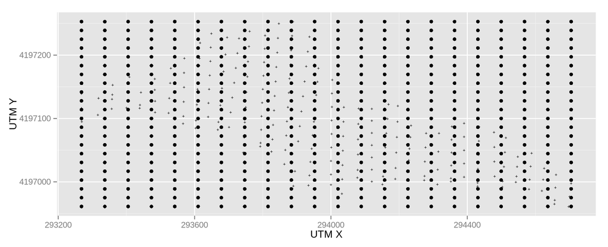

```r
base.plot + geom_point(data=grids[['grid_identical']])
```

- *build_grid_proportional*:

```r
nrow(grids[['grid_proportional']]) # Total number of points in grid
```

```
## [1] 500
```

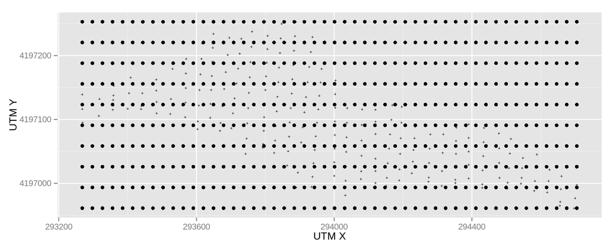

```r
base.plot + geom_point(data=grids[['grid_proportional']])
```

- *build_grid_ahull_crop*:

```r
nrow(grids[['ahull_crop']]) # Total number of points in grid
```

```
## [1] 184
```

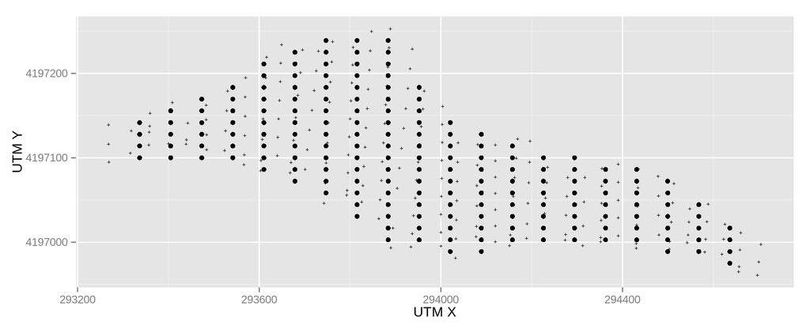

```r
base.plot + geom_point(data=grids[['ahull_crop']])
```

- *build_grid_ahull_fill*: takes much longer to run but gives a number of points that correspond approximately to what was requested

```r
nrow(grids[['ahull_fill']]) # Total number of points in grid
```

```
## [1] 482
```

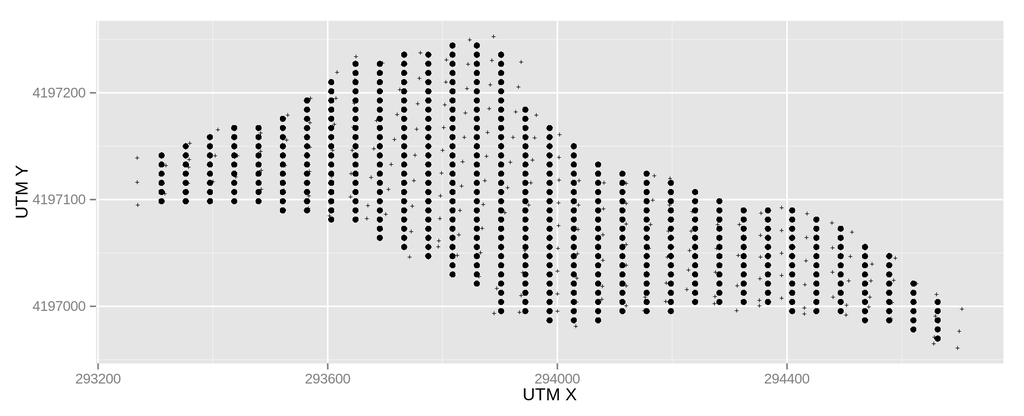

```r
base.plot + geom_point(data=grids[['ahull_fill']])
```